# Mapeo transporte publico

Ari e Ine

9/13/2021

# Objetivos del día

- Retomando: Hasta ahora tenemos mas o menos definidos lo que consideramos espacio publico pero nos falta ultimar
- Objetivos:
1. Construir un criterio que nos permita seleccionar un subconjunto de poligonos que represente lo que nosotres entendemos por espacio verde / parque. Este criterio podría ser como una lista de items que combine tanto criterios conceptuales (indicando lo que estamos buscando capturar) como criterios numéricos o mecánicos (indicando en efecto cómo los seleccionamos). Respecto a esto, algunas ideas:
- Corte de área
- Corte de diámetro (al menos que el polígono tenga $a \times b$ metros cuadrados, indicando valores mínimos para $a$ y $b$).
- Que se encuentre en ambos datasets.
- Que sea completamente público.
- Se aceptan otros!
2. Definir algun criterio o **score** de calidad de cada espacio verde de a cuerdo a los servicios que ofrece.
3. Mapear y filtrar las distintas formas de transporte publico:

Aca creo que tenemos de nuevo dos opciones, OSM y el gobierno de la ciudad. OSM esta bastante bien y sabemos como suarlo. El gobierno tiene los datos guardados en una API (https://www.buenosaires.gob.ar/desarrollourbano/transporte/apitransporte). Deberiamos ver como catzo haevrlo funcionar.

# Libraries

```r
library(tidyverse)
library(sf)
library(ggmap)
library(leaflet)
library(osrm)
library(osmdata)
library("RColorBrewer")
```

# Descarga de Transporte público usando OSM

OSM tiene una key para transporte publico https://wiki.openstreetmap.org/wiki/Map_features#Public_Transport voy a empezar usando solo el *stop_position* que nos va a dar una idea de la posicion, luego podemos sumar mos cosas interesantes como *platform*.

Descarga de bbbox y creacion del mapa

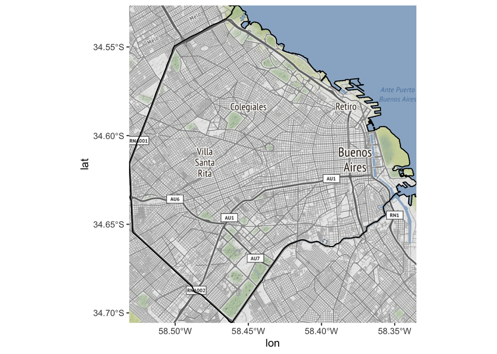

```r
bbox_ba <- getbb("Buenos Aires, Argentina")
mapa_ba <- get_stamenmap(bbox_ba,  zoom = 12)

polygon_ba <- getbb("Buenos Aires, Argentina",
                            format_out = "sf_polygon")

ggmap(mapa_ba)+
  geom_sf(data=polygon_ba$multipolygon, fill=NA, size=0.5, color="black", inherit.aes = FALSE)
```

Descarga de transporte publico, parece tener paradas de bondy, ferry, etc

```r
paradas_ba <- opq(bbox_ba) %>%
                    add_osm_feature(key = "public_transport", value = "stop_position")

paradas_ba  <- osmdata_sf(paradas_ba )

#extraemos los puntos
paradas_ba   <- paradas_ba$osm_points
```

Exploro

```r
names(paradas_ba)
```

```
##  [1] "osm_id"            "name"              "aerialway"
##  [4] "alt_name"          "bus"               "covered"
##  [7] "description"       "ferry"             "funicular"
## [10] "highway"           "light_rail"        "local_ref"
## [13] "man_made"          "monorail"          "name.en"
## [16] "network"           "note"              "official_name"
## [19] "old_name"          "operator"          "platforms"
## [22] "public_transport"  "railway"           "railway.position"
## [25] "share_taxi"        "shelter"           "short_name"
## [28] "source"            "start_date"        "subway"
## [31] "surveillance"      "surveillance.type" "surveillance.zone"
## [34] "tactile_paving"    "traffic_calming"   "train"
## [37] "tram"              "trolleybus"        "unknown"
## [40] "wheelchair"        "wikidata"          "wikipedia"
## [43] "geometry"
```

```r
unique(paradas_ba$train)
```

```
## [1] "yes" NA    "no"
```

Grafico

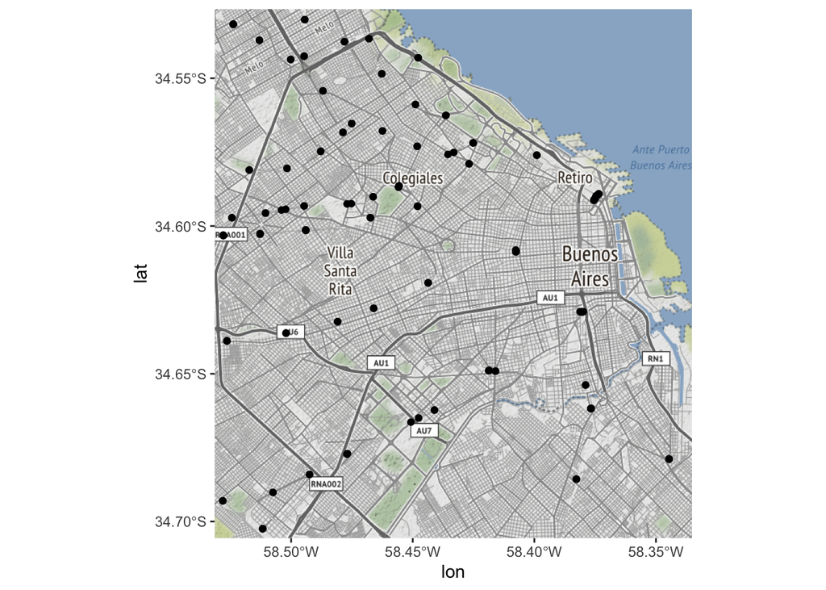

```r
# me da miedo mapear todo asi que voy a poner solo tren
ggmap(mapa_ba)+
  geom_sf(data =  paradas_ba %>% filter(train == "yes"), inherit.aes = FALSE)
```